# Week 8: Confidence Intervals and Hypothesis Testing

PS 812 - Introduction to Statistical Methods in Political Science

Anton Strezhnev

strezhnev@wisc.edu

University of Wisconsin-Madison

October 27, 2026

## Welcome back!

$$\newcommand{\Var}{\text{Var}}
\newcommand{\Cov}{\text{Cov}}
\newcommand{\Corr}{\text{Corr}}
\newcommand{\indep}{\mathrel{\perp\mkern-10mu\perp}}$$

## Where we’ve been

Adapted from Blackwell (2025), Ch. 2

## Where we’ve been

- Under **i.i.d random sampling** from the target population, the **central limit theorem** gives us…

$\sqrt{n}\left(\hat{\mu} - \mu\right) \xrightarrow{d} \mathcal{N}\left(0, \sigma^2\right)$

- **Intuition**: Averaging washes out every feature of the distribution beyond the mean and variance:
  - And the **normal** is the distribution **fully defined** by mean and variance alone
    - All odd central moments $\ge 3$ are zero
    - All even central moments $\ge 4$ are functions of $\Var(X)$

## This week

- **Confidence intervals**
  - **Interval estimator** - An *upper* and *lower* bound constructed to *cover* the true parameter in some percentage of repeated samples.
  - Constructing confidence intervals under **asymptotic normality**
  - Small sample coverage rates and some typical corrections.
- **Hypothesis testing**
  - Statistical **decision making** through thought experiments.
  - **Given** some assumed value of the population parameter, how likely would I be to observe what I find in my sample (or more extreme)?
  - This is a **p-value**. If it’s sufficiently low, I may be willing to believe that the population parameter is **not** the hypothesized value.
- Connections between **confidence intervals** and **hypothesis testing**

## Point estimation

## Interval estimation

## Motivation: ANES (2024) - Attitudes towards the parties

## Motivation: ANES (2024) - Attitudes towards the parties

- Do Americans feel more warmly towards the **Democratic** party or the **Republican** party?
  - The 2024 American National Election Study (ANES) asks respondents to rate each party on a 0-100 feeling thermometer.

```r
library(tidyverse)
# 2024 ANES pre-election wave
anes <- read_csv("data/anes24_therm.csv") |>
  filter(!is.na(ft_dem), !is.na(ft_rep)) |>
  mutate(ft_diff = ft_dem - ft_rep)   # Dem minus Rep for each respondent
```

- We’ll use a sample mean estimator for the *within-respondent* difference
  - As before, we’ll ignore the sample weights for now…

```r
anes |> summarize(mean_ft_dem = mean(ft_dem),
                    mean_ft_rep = mean(ft_rep),
                    mean_ft_diff = mean(ft_diff))
```

```
# A tibble: 1 × 3
  mean_ft_dem mean_ft_rep mean_ft_diff
        <dbl>       <dbl>        <dbl>
1        45.7        43.4         2.28
```

- On average, respondents feel 2.28 points *more warmly* towards the Democrats?
  - But how confident are we that the truth isn’t **zero**?

## Attitudes towards the parties

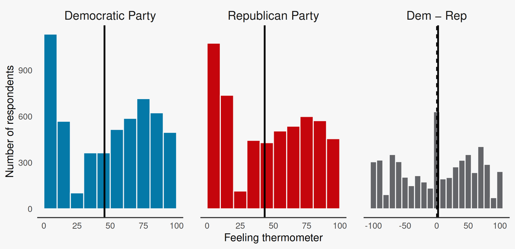

## Attitudes towards the parties

- We can calculate an estimate of the **standard error** of the mean using our formula from before

  $$\widehat{SE}(\bar{Y}) = \frac{\hat{\sigma}}{\sqrt{n}} = \frac{\sqrt{\frac{1}{n-1}\sum_{i=1}^n \left(Y_i - \bar{Y}\right)^2}}{\sqrt{n}}$$

```r
anes |> summarize(mean_ft_diff = mean(ft_diff),
                  n=n(),
                  sd_ft_diff = sd(ft_diff),
                  se_ft_diff = sd_ft_diff/sqrt(n))
```

```
# A tibble: 1 × 4
  mean_ft_diff     n sd_ft_diff se_ft_diff
         <dbl> <int>      <dbl>      <dbl>
1         2.28  5477       59.7      0.807
```

- In terms of **RMSE**, our estimator is 0.807 units from the true mean…which is about a third of our estimate - not *too* big but still sizeable.
  - It’s entirely plausible though that we could have obtained our estimate in a world where the true difference is **zero**.
  - Can we quantify our uncertainty in a more transparent and rigorous way?

## Confidence interval

- A **confidence interval** is an estimator that consists of an *upper* and a *lower* bound.
  - These bounds are constructed to have a particular **coverage rate**
- A $100(1-\alpha)\%$ **confidence interval** for population parameter $\theta$ is an interval $[l, u]$ where $l = l(Y_1, Y_2, \dotsc, Y_n)$ and $u = u(Y_1, Y_2, \dotsc, Y_n)$ are functions of the data such that

  $$P(l \le \theta \le u) = 1 - \alpha$$
- The **bounds** are random variables
  - They’re functions of the data - just like our sample mean estimator

## Confidence intervals under asymptotic normality

- How can we derive a confidence interval for the **population mean** $\mu$
  - We’ll need to calculate the **probability** of drawing an interval that either does or does not cover the target.
  - This means we need the **distribution** of our estimator - mean and variance alone aren’t enough!
  - That’s why we spent so much time on the **central limit theorem** - in large samples we can approximate the sampling distribution with a **normal**.
- We’ll focus on an interval that is **symmetric** and **centered on the sample mean**

  $$P(\underbrace{\bar{Y} - c}_{\text{lower}} \le \mu \le \underbrace{\bar{Y} + c}_{\text{upper}}) = 1 - \alpha$$

## Confidence intervals under asymptotic normality

- Rearrange the probability so that the **estimator** is in the middle
  $$\begin{aligned}
  P(\bar{Y} - c \le \mu \le \bar{Y} + c) &= P(-c \le \mu - \bar{Y} \le c) && \small\color{#777777}{\text{subtract } \bar{Y} \text{ throughout}} \\
  &= P(-c \le \bar{Y} - \mu \le c) && \small\color{#777777}{\text{multiply by } -1} \\
  &= P\left(-\frac{c}{SE(\bar{Y})} \le \frac{\bar{Y} - \mu}{SE(\bar{Y})} \le \frac{c}{SE(\bar{Y})}\right) && \small\color{#777777}{\text{divide by } SE(\bar{Y}) = \sigma/\sqrt{n} > 0}
  \end{aligned}$$
- The term in the middle is the **standardized** sample mean
  $$\frac{\bar{Y} - \mu}{SE(\bar{Y})} = \frac{\bar{Y} - \mu}{\sigma/\sqrt{n}} = \frac{\sqrt{n}(\bar{Y} - \mu)}{\sigma}$$
- If we knew its **distribution**, we could choose $c$ to make the probability exactly $1 - \alpha$

## Confidence intervals under asymptotic normality

- Last week we used the **central limit theorem** to show that

  $$\sqrt{n}(\bar{Y} - \mu) \xrightarrow{d} \mathcal{N}(0, \sigma^2)$$
- And, by extension (continuous mapping theorem), the standardized mean is asymptotically **standard normal**

  $$\frac{\sqrt{n}(\bar{Y} - \mu)}{\sigma} \xrightarrow{d} \mathcal{N}(0, 1)$$
- We now have a **pivotal quantity** - a function of the data and parameter whose (limiting) distribution **does not depend** on any unknowns.

## Confidence intervals under asymptotic normality

- Now we just need to find the value of $c$ that satisfies

  $$P\left(-\frac{c}{SE(\bar{Y})} \le \frac{\bar{Y} - \mu}{SE(\bar{Y})} \le \frac{c}{SE(\bar{Y})}\right) = 1 - \alpha$$
- The probability of landing in an *interval* is just **difference of two CDFs**. Let $\Phi()$ be the **standard normal** CDF

  $$\begin{aligned}
  &= P\left(\frac{\bar{Y} - \mu}{SE(\bar{Y})} \le \frac{c}{SE(\bar{Y})}\right) - P\left(\frac{\bar{Y} - \mu}{SE(\bar{Y})} < -\frac{c}{SE(\bar{Y})}\right) && \small\color{#777777}{\text{upper minus lower}} \\
  &\approx \Phi\left(\frac{c}{SE(\bar{Y})}\right) - \Phi\left(-\frac{c}{SE(\bar{Y})}\right) && \small\color{#777777}{\text{asymptotic normality}} \\
  &= \Phi\left(\frac{c}{SE(\bar{Y})}\right) - \left[1 - \Phi\left(\frac{c}{SE(\bar{Y})}\right)\right] && \small\color{#777777}{\text{symmetry: } \Phi(-x) = 1 - \Phi(x)} \\
  &= 2\Phi\left(\frac{c}{SE(\bar{Y})}\right) - 1
  \end{aligned}$$

## Confidence intervals under asymptotic normality

$$P\left(-\frac{c}{SE(\bar{Y})} \le \frac{\bar{Y} - \mu}{SE(\bar{Y})} \le \frac{c}{SE(\bar{Y})}\right)$$

## Confidence intervals under asymptotic normality

- Set the probability equal to $1 - \alpha$ and solve for $c$ using the **inverse CDF** $\Phi^{-1}()$

  $$\begin{aligned}
  2\Phi\left(\frac{c}{SE(\bar{Y})}\right) - 1 &= 1 - \alpha \\
  \Phi\left(\frac{c}{SE(\bar{Y})}\right) &= 1 - \frac{\alpha}{2} && \small\color{#777777}{\text{add 1, divide by 2}} \\
  \frac{c}{SE(\bar{Y})} &= \Phi^{-1}\left(1 - \frac{\alpha}{2}\right) && \small\color{#777777}{\text{apply the inverse CDF}} \\
  c &= \Phi^{-1}\left(1 - \frac{\alpha}{2}\right) \times SE(\bar{Y})
  \end{aligned}$$
- The **critical value** $z_{1-\alpha/2} = \Phi^{-1}(1 - \alpha/2)$ is the $1 - \alpha/2$ quantile of the standard normal
  - By symmetry, we allocate $\alpha/2$ probability to each tail.
- For a 95% interval, $\alpha = 0.05$ and $z_{0.975} \approx 1.96$ (`qnorm(0.975)` in R)

## Confidence intervals under asymptotic normality

$$\Phi(z_{0.975}) = \int_{-\infty}^{z_{0.975}} \frac{1}{\sqrt{2\pi}} e^{-z^2/2}\,dz = 0.975 \quad \Longleftrightarrow \quad z_{0.975} = \Phi^{-1}(0.975)$$

## Critical values and coverage

$$P\left(-z \le \frac{\bar{Y} - \mu}{SE(\bar{Y})} \le z\right) \approx 2\Phi(z) - 1$$

## Plugging in the estimated standard error

- Our two-sided $100(1-\alpha)\%$ confidence interval is

  $$\left[\bar{Y} - z_{1-\alpha/2}\frac{\sigma}{\sqrt{n}},\ \ \bar{Y} + z_{1-\alpha/2}\frac{\sigma}{\sqrt{n}}\right]$$
- Unfortunately, we don’t know $\sigma$! So let’s plug in our estimated $\hat{\sigma}$ instead.

  $$\left[\bar{Y} - z_{1-\alpha/2}\widehat{SE}(\bar{Y}),\ \ \bar{Y} + z_{1-\alpha/2}\widehat{SE}(\bar{Y})\right], \qquad \widehat{SE}(\bar{Y}) = \frac{\hat{\sigma}}{\sqrt{n}}$$
- Is this valid? Yes, by **Slutsky’s theorem**, if $\hat{\sigma} \xrightarrow{p} \sigma$, then

  $$\frac{\bar{Y} - \mu}{\widehat{SE}(\bar{Y})} = \frac{\overbrace{\sqrt{n}(\bar{Y} - \mu)}^{\xrightarrow{d} \mathcal{N}(0, \sigma^2)}}{\underbrace{\hat{\sigma}}_{\xrightarrow{p} \sigma}} \xrightarrow{d} \frac{1}{\sigma}\mathcal{N}(0, \sigma^2) = \mathcal{N}(0, 1)$$
- Our normalized mean with the estimated standard error is still asymptotically **standard normal**.

## Attitudes towards the parties

```r
anes |> summarize(est = mean(ft_diff),
                  se = sd(ft_diff) / sqrt(n()),
                  lower = est - qnorm(0.975) * se,
                  upper = est + qnorm(0.975) * se)
```

```
# A tibble: 1 × 4
    est    se lower upper
  <dbl> <dbl> <dbl> <dbl>
1  2.28 0.807 0.699  3.86
```

- Our 95% confidence interval for the average Dem $-$ Rep difference is $[0.70, 3.86]$
- **Interpretation**: We are *95% confident* that the true population difference in Dem vs. Rep thermometers is between $[0.70, 3.86]$
- This **does not mean** that there is a 95% *probability* that the true difference lies between $[0.70, 3.86]$
  - $\mu$ is fixed - it either *is* or *isn’t* in this particular interval.
  - The bounds are the **estimator** - they have randomness under repeated sampling.
  - The specific bounds we calculate are the **estimate**

## Interpreting Confidence Intervals

## Small sample confidence intervals

## Small sample confidence intervals

## Small sample confidence intervals

- Our 95% confidence interval from above is a **large sample** approximation
  - Relies on $\frac{\sqrt{n}(\bar{Y} - \mu)}{\hat{\sigma}} \xrightarrow{d} \mathcal{N}(0, 1)$
- Even if our data were **normally distributed**, $Y_i \overset{\text{i.i.d.}}{\sim} \mathcal{N}(\mu, \sigma^2)$, the asymptotic confidence interval is not quite exact
  - Because we’re **estimating** the standard error.
- Getting exact coverage guarantees for our confidence intervals in a **finite sample** requires some additional assumptions.
  - Our sampling distribution may also not be **normal** in finite samples.
- Student (1908) showed that for **normally distributed** data, $Y_i \overset{\text{i.i.d.}}{\sim} \mathcal{N}(\mu, \sigma^2)$ where $\hat{\sigma^2}$ is the unbiased sample variance estimator:

  $$T = \frac{\sqrt{n}(\bar{Y} - \mu)}{\hat{\sigma}} \sim t_{(n-1)}$$
- $t_{(n-1)}$ is the **t**-distribution with $n-1$ “degrees of freedom”

## Small sample confidence intervals

- The **t** distribution is the ratio of a **standard normal** and the square root of an independent **chi-squared** divided by its **degrees of freedom**.

  $$T = \frac{\sqrt{n}(\bar{Y} - \mu)}{\hat{\sigma}} = \underbrace{\frac{\sqrt{n}(\bar{Y} - \mu)}{\sigma}}_{\text{Normal}(0, 1)} \times \left(\underbrace{\frac{(n-1)\hat{\sigma}^2}{\sigma^2}}_{\chi^2_{(n-1)}} \bigg/ (n-1)\right)^{-1/2}$$
- The **chi-squared** distribution is the distribution of the sum of *squared* i.i.d. standard normals.
  - The parameter is the *number* of independent normals being summed - typically referred to as the “degrees of freedom”
  - Under normality, $\frac{(n-1)\hat{\sigma}^2}{\sigma^2} = \sum_{i=1}^n \left(\frac{Y_i - \bar{Y}}{\sigma}\right)^2$ is the sum of $n$ squared normal deviations.
  - But $\sum_{i=1}^n (Y_i - \bar{Y}) = 0$. Once we know $n-1$ of the outcomes, the last is fixed. So it behaves like a sum of only $n-1$ *independent* squared standard normals: $\chi^2_{(n-1)}$

## The t-distribution

$\bar{Y} \pm$ 1.960 $\times \widehat{SE}(\bar{Y})$

## t-distribution critical values

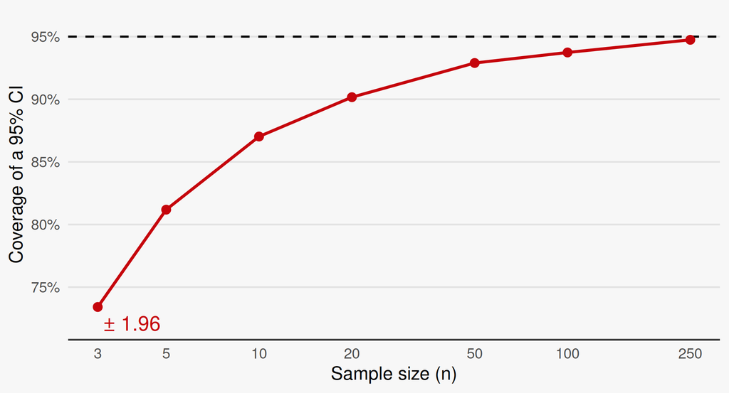

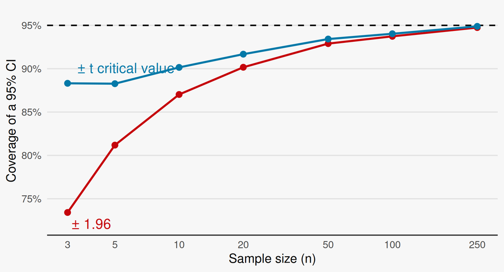

$Y_i \overset{\text{i.i.d.}}{\sim} \text{Exponential}(1)$, 20,000 samples per $n$

## One-sided confidence intervals

- Most of the time, researchers present two-sided and symmetric confidence intervals.
  - But there’s nothing saying that we **have** to be symmetric or two-sided!
  - It just depends on where we want to allocate our “coverage failure” $\alpha$.
- We could instead stack it all on one side and construct a **one-sided** confidence interval!

  $$P( \theta \le u) = 1 - \alpha$$
- For an asymptotically normal CI of the sample mean, this is just

  $$u = \bar{Y} + z_{1-\alpha}\frac{\hat{\sigma}}{\sqrt{n}}$$
- For a 95% interval, $\alpha = 0.05$ and $z_{0.95} \approx 1.645$ (`qnorm(0.95)` in R)
  - We’ve narrowed the upper bound a bit in exchange for an arbitrary lower bound $-\infty$.
  - Equivalent idea for a one-sided **lower bound**

## One-sided confidence intervals

## Hypothesis Testing

- Another approach to thinking about **uncertainty** in our estimator is from the perspective of **evaluating hypotheses**
- Assume a particular “truth” about the parameter we want to learn about.
  - Calculate the probability of observing our sample **given** this assumption.
  - A sufficiently **unlikely** sample may persuade us that our assumption should be rejected.
- The “null hypothesis statistical testing” (NHST) paradigm is **ubiquitious** in science.
  - Combines ideas from both Fisher (1925) and Neyman-Pearson (1933) approaches to hypothesis tests.

## General Framework

1. Choose a **null** $H_0$ and an **alternative** $H_a$ hypothesis about some feature of the population
2. Choose a **test statistic** $T$ that is a function of the data we observe $T(Y_1, Y_2, \dotsc, Y_n)$
3. Choose a desired **Type I** (false positive) error rate
4. Find the distribution of the test statistic under the null hypothesis
5. Define the **rejection region** for the chosen error rate in terms of values of the test statistic
6. Calculate whether the observed test statistic falls in the rejection region
7. If it does, reject the null. Otherwise, **fail** to reject the null.

## Null and Alternative Hypotheses

- The **null hypothesis** is the statement we wish to find evidence against.
  - Usually a “baseline” assumption: “no effect/difference/deviation from what’s already known”
  - We denote this as $H_0: \mu = \mu_0$
- The **alternative hypothesis** is the research claim we wish to make
  - “There is an effect/difference/deviation from baseline”
  - We denote this as $H_a: \mu \neq \mu_0$
- Ex: The **average** population difference between Democratic and Republican feeling thermometer ratings
  - **Null Hypothesis**: $H_0: \mu = 0$ - The population average is **zero**
  - **Alternative Hypothesis**: $H_a: \mu \neq 0$ - The population average is **not** zero
- Most of the time we see **two-sided** hypothesis tests ($\neq$)
  - We are willing to reject in favor of a difference in **either** direction.
  - Sometimes (though rarely), we might **only** want to reject the null if the result is in a particular direction.
  - $H_0: \mu = 0, H_a: \mu > 0$

## Step 1: Null and alternative hypotheses

## Choosing a test statistic

- Given a particular null and alternative, we want to choose a **test statistic** that will be large *if* the null is false (and not too large if it is true).
  - We also want to know (or be able to calculate) the distribution of the test statistic **under the null**
- Our most common test statistic is the **t-statistic** (esp. for tests based on asymptotic normality):

  $$T = \frac{\hat{\mu} - \mu_0}{\widehat{SE}(\hat{\mu})}$$
- Ex. For testing the null of $\mu = 0$ difference in Democratic v. Republican feeling thermometers using the **sample mean** estimator

  $$T = \frac{\bar{Y} - 0}{\hat{\sigma}/\sqrt{n}}$$
- We’ve shown that under the null $T$ is **asymptotically** standard normal

  $$T \overset{a}{\sim} \mathcal{N}(0, 1)$$

## The test statistic

## False Positives and False Negatives

- At the end of the test we will either **reject** the null $H_0$ in favor of $H_a$ or **fail to reject**
  - Each of these decisions carries with it a risk of **error**
- **Type I** error or **false positives**
  - We **reject** the null even though it is **true**
- **Type II** error or a **false negative**
  - We **fail** to reject the null when it is **false**.

|  | $H_0$ **true** | $H_0$ **false** |
| --- | --- | --- |
| **Retain** $H_0$ | Correct | **Type II** error (false negative) |
| **Reject** $H_0$ | **Type I** error (false positive) | Correct |

## Size and Power of a Test

- In NHST, we directly control the **Type I** or **False positive rate**
  - This is because we only have probabilities **given** $H_0$ is *true*
- The **level** or **size** of our test, denoted $\alpha$ is our chosen probability of a **Type I** error.
- Our choice of level depends on how much we’d like to avoid a false discovery
  - In social sciences, typical convention is $\alpha = .05$ - but this is arbitrary!
  - To detect the Higgs Boson, CERN physicists used $\alpha = 1 - \Phi(5) = 2.87 \times 10^{-7}$
- Choosing a **low** Type I error trades off a potentially **higher** Type II error (more false negatives)
  - The **power** of a test is defined as $1 - Pr(\text{False negative})$
  - This is in part a function of our chosen Type I error, but also a function of an **unknown**: the true parameter value (relative to the sampling variance of our estimator)
  - We’ll often calculate power before running our study under **hypothesized** values of the parameter to figure out how large of an effect our study can plausibly detect.
    - You’ll be doing this in section this week!

## The Type I error rate

## The null distribution

## The rejection region

- Once we know the distribution of the **test statistic** under the null, we need to decide what **realizations** of the test statistic will lead to a decision of **rejecting** $H_0$
  - This is known as the **rejection region** for the test.
  - How large of a $T$ will lead us to conclude in favor of the alternative?
- To do this, we need to find the value $c$ such that

  $$Pr(-c \le T \le c) = 1 - \alpha$$
- For a **two-sided** test, $H_a: \mu \neq \mu_0$, we’ll allocate our “$\alpha$ budget” symmetrically to both tails of the test statistic distribution
  - Equivalent to $Pr(|T| \le c) = 1 - \alpha$

## The rejection region

- For an **asymptotically standard normal** test statistic, our critical values should look familiar

  $$\begin{aligned}
  Pr(-c \le T \le c) &\approx \Phi(c) - \Phi(-c) && \small\color{#777777}{\text{difference of two CDFs}} \\
  &= \Phi(c) - \left[1 - \Phi(c)\right] && \small\color{#777777}{\text{symmetry: } \Phi(-x) = 1 - \Phi(x)} \\
  &= 2\Phi(c) - 1
  \end{aligned}$$
- Setting this equal to $1 - \alpha$ and solving for $c$

  $$\begin{aligned}
  2\Phi(c) - 1 &= 1 - \alpha \\
  \Phi(c) &= 1 - \frac{\alpha}{2} && \small\color{#777777}{\text{add 1, divide by 2}} \\
  c &= \Phi^{-1}\left(1 - \frac{\alpha}{2}\right) = z_{1 - \alpha/2} && \small\color{#777777}{\text{apply the inverse CDF}}
  \end{aligned}$$
- **Reject** $H_0$ if $|T| > z_{1-\alpha/2}$. For $\alpha = 0.05$, reject if $|T| > 1.96$ - the same critical value as our 95% confidence interval!

## The rejection region

## The decision

## p-values

- The **p-value** for a particular hypothesis test is the probability of observing a test statistic **at least as extreme as** the one we observe in the sample **given that the null is true**
  - If the p-value falls below our chosen $\alpha$, we **reject** the null
- The **smallest** $\alpha$ for which we would still reject our null hypothesis.
  - Calculate using `2*pnorm(-abs(T))` for a two-sided asymptotically normal test.
- Be careful! P-values are **not**…
  - …evidence that the effect is **substantively** significant
  - …the probability that the null hypothesis is true $P(H_0 \text{ true}|\text{observed data}) \neq P(\text{observed data} | H_0 \text{ true})$
  - …the probability that the alternative is true (all probabilities here are **conditional** on the null)

## Connection to confidence intervals

- Confidence intervals and hypothesis tests have a **dual** relationship
  - A $100(1-\alpha)\%$ **confidence interval** contains all of the null hypotheses that we’d **fail to reject** with an $\alpha$ level test.
- Two-sided CIs correspond to two-sided hypothesis tests.
  - *One-sided CIs* correspond to one-sided hypothesis tests.
- This relationship also gives us a way of generating a confidence interval if **all we have** is a hypothesis test (e.g. randomization tests in ps813).
  - Vary $\mu_0$ across some range of values
  - Conduct the hypothesis test at each value
  - Collect all the values where $p$ is greater than $\alpha$.
  - That’s our $100(1-\alpha)\%$ interval!

## Connection to confidence intervals

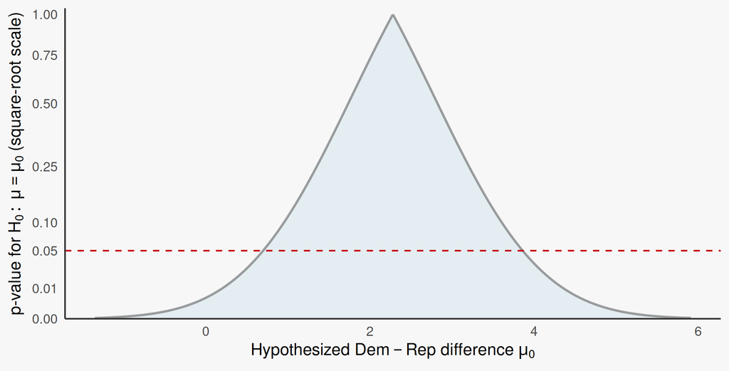

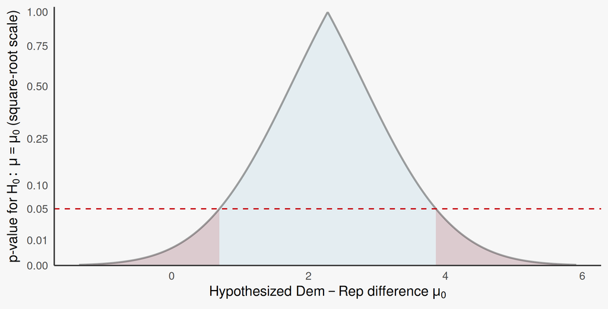

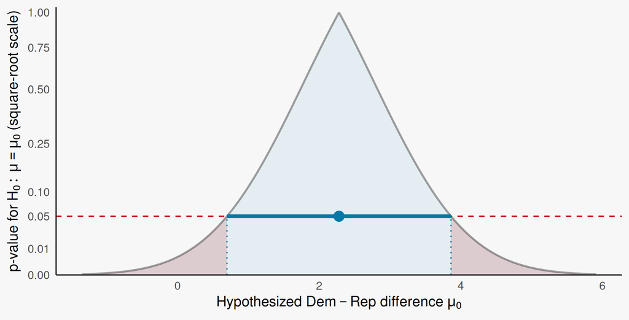

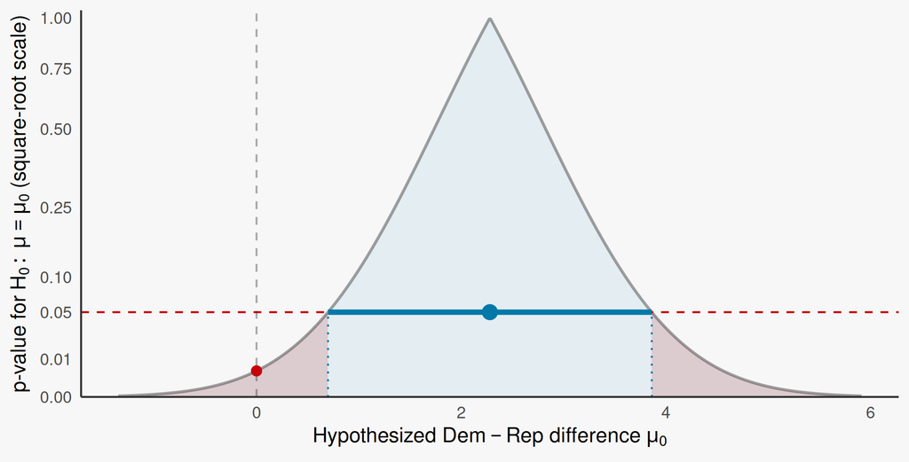

## Bonferroni correction

- When testing multiple hypotheses, we want to **control** the global error rate of the full “family” of tests
- One error rate we could target is **family-wise error rate**

  $$\text{FWER} = P(\text{at least one rejection} | \text{All nulls are true})$$
- We can write this using the complement

  $$\text{FWER} = 1 - P(\text{fail to reject all tests} | \text{All nulls are true})$$
- If I have $K$ **independent tests** where I reject *each* at the rate $\alpha$, my FWER is

  $$\begin{aligned}
  \text{FWER} &= 1 - P(\text{fail to reject all } K | \text{All nulls are true}) \\
  &= 1 - \textstyle\prod_{k=1}^K P(\text{fail to reject } H_{0k} | H_{0k} \text{ true}) && \small\color{#777777}{\text{independence}} \\
  &= 1 - \textstyle\prod_{k=1}^K (1 - \alpha) && \small\color{#777777}{\text{Type I error rate } \alpha} \\
  &= 1 - (1 - \alpha)^K
  \end{aligned}$$

## Bonferroni correction

  $$\begin{aligned}
  \text{FWER} &= P\left(\textstyle\bigcup_{k=1}^K \{\text{reject } H_{0k}\} \,\middle|\, \text{All nulls are true}\right) \\
  &\le \textstyle\sum_{k=1}^K P(\text{reject } H_{0k} | H_{0k} \text{ true}) && \small\color{#777777}{\text{union bound}} \\
  &\le K \times \frac{\alpha}{K} = \alpha && \small\color{#777777}{\text{each test at level } \alpha / K}
  \end{aligned}$$
- Ex: $K = 20$ tests at $\alpha = 0.05$. We’d reject each null only if $p < 0.0025$ - $|T| > 3.02$ instead of $1.96$
  - The consequence is a much higher bar for each test: **lower power** and more false negatives.

## Holm correction

- An alternative approach is the **Holm** step-down procedure (Holm 1979)
  - Also controls the FWER at $\alpha$ (for any dependence)
  - Rejects **at least** as often as Bonferroni (so more power)
- The **Holm** testing approach:
  1. Sort the p-values from smallest to largest: $p_{(1)} \le p_{(2)} \le \dotsc \le p_{(K)}$
  2. Start at $k = 1$: if $p_{(k)} \le \frac{\alpha}{K - k + 1}$, reject $H_{0(k)}$ and move on to $k + 1$
  3. **Stop** at the first $p_{(k)} > \frac{\alpha}{K - k + 1}$: fail to reject $H_{0(k)}$ and **every** hypothesis after it
- The bar **relaxes** as we go - first step is just Bonferroni:

  $$\underbrace{\frac{\alpha}{K}}_{k = 1}, \quad \underbrace{\frac{\alpha}{K - 1}}_{k = 2}, \quad \underbrace{\frac{\alpha}{K - 2}}_{k = 3}, \quad \dotsc, \quad \underbrace{\frac{\alpha}{1}}_{k = K}$$
- Two equivalent ways to correct: shrink the **threshold** $(p_k < \alpha/K)$ or inflate the **p-value** $(K p_k < \alpha)$
  - In R, `p.adjust(p, method = "holm")` (or `"bonferroni"`) returns **adjusted p-values** we can compare to $\alpha$ as if it were a single test

## Multiple testing

## Bonferroni and Holm

## Attitudes towards the parties by age

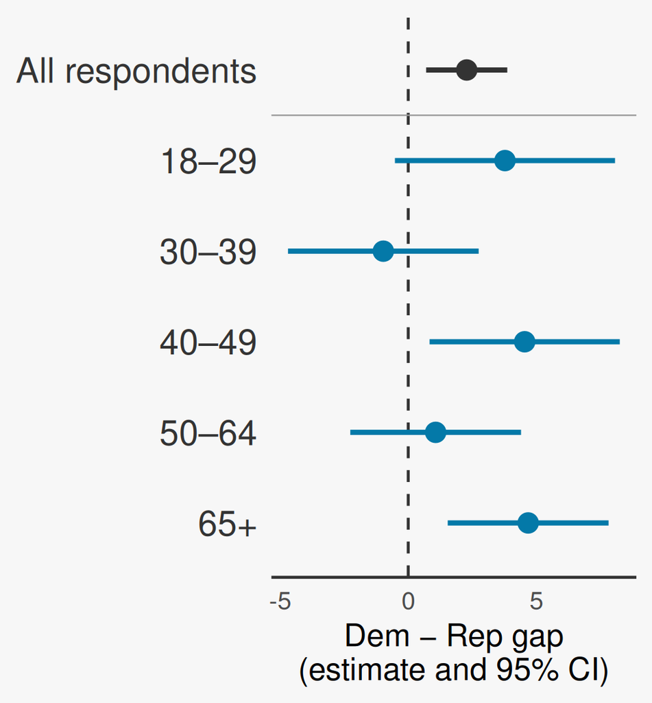

|  | All (1) | Age group 18–29 (2) | Age group 30–39 (3) | Age group 40–49 (4) | Age group 50–64 (5) | Age group 65+ (6) |
| --- | --- | --- | --- | --- | --- | --- |
| Dem − Rep gap | 2.28** | 3.77 | −0.97 | 4.54* | 1.07 | 4.68** |
|  | (0.81) | (2.19) | (1.90) | (1.89) | (1.70) | (1.60) |
| N | 5,477 | 547 | 833 | 870 | 1,276 | 1,680 |

Estimates are mean Dem − Rep thermometer differences; standard errors in parentheses. Two-sided tests of H₀: μ = 0: * p < 0.05, ** p < 0.01, *** p < 0.001.

## Caution with NHST

- The American Statistical Association’s statement on p-values (Wasserstein and Lazar 2016)
  1. P-values can indicate how **incompatible** the data are with a specified statistical model
  2. P-values **do not** measure the probability that the studied hypothesis is true, or the probability that the data were produced by random chance alone.
  3. Scientific conclusions and business or policy decisions should not be based **only** on whether a p-value passes a specific threshold.
  4. Proper inference requires **full reporting** and transparency.
  5. A p-value, or statistical significance, does not measure the size of an effect or the **importance** of a result.
  6. By itself, a p-value does not provide a good measure of evidence regarding a model or hypothesis.
- A p-value is $P(\text{data at least this extreme} | H_0)$, **not** $P(H_0 | \text{data})$

## Caution with NHST

- **“Significant” vs. “not significant” is not itself significant** (Gelman and Stern 2006)
  - 65+ is “significant” and 18–29 is not - but the difference between them is 0.90 (SE 2.71), nowhere near significant!
- **Researcher degrees of freedom** - “p-hacking” and the “garden of forking paths” (Simmons et al. 2011; Gelman and Loken 2014)
  - Many choices of sample, outcome, controls and subgroups - an implicit **multiple testing** problem even if only one test is reported
- **Publication bias** - journals (and authors) favor results that clear $p < 0.05$ (Gerber and Malhotra 2008)
  - Published estimates often bunch *just* past the critical value.

## Caution with NHST

- **The significance filter** (Gelman and Carlin 2014)
  - In low-powered studies, the estimates that pass the threshold **exaggerate** the effect (Type M)
  - And very often have the wrong sign (Type S)
- **Meaning of a null**
  - Some failures to reject are genuinely **informative** zeroes (Rainey 2014; Hartman and Hidalgo 2018)
  - Failures for underpowered studies are often **uninformative**. Those studies would likely fail to detect most **substantively interesting** effects (Arel-Bundock et al. 2026).
- **Proposed fixes**
  - Stricter default threshold ($p < 0.005$) (Benjamin et al. 2018)
  - Abandon “statistical significance” altogether in favor of reporting estimates + ranges of values “compatible” with the data (Amrhein et al. 2019)

## Next week

- **Regression**
  - How do we model the **conditional expectation** of $Y$ as $X$ changes
  - Flexible but noisy methods: binned scatterplots, kernel estimators
  - More precise but need **assumptions**: ordinary least squares
- **Plug-in estimator** for the “best linear predictor”
  - Later: Interpreting the BLP as the CEF.

## References

Amrhein, Valentin, Sander Greenland, and Blake McShane. 2019. “Scientists Rise up Against Statistical Significance.” *Nature* 567 (7748): 305–7. https://doi.org/10.1038/d41586-019-00857-9.

Arel-Bundock, Vincent, Ryan C. Briggs, Hristos Doucouliagos, Marco M. Mendoza Aviña, and T. D. Stanley. 2026. “Quantitative Political Science Research Is Greatly Underpowered.” *The Journal of Politics* 88 (1): 36–46. https://doi.org/10.1086/734279.

Benjamin, Daniel J., James O. Berger, Magnus Johannesson, Brian A. Nosek, E.-J. Wagenmakers, et al. 2018. “Redefine Statistical Significance.” *Nature Human Behaviour* 2 (1): 6–10. https://doi.org/10.1038/s41562-017-0189-z.

Blackwell, Matthew. 2025. *A User’s Guide to Statistical Inference and Regression*. https://mattblackwell.github.io/gov2002-book/.

Fisher, Ronald A. 1925. *Statistical Methods for Research Workers*. Oliver; Boyd.

Gelman, Andrew, and John Carlin. 2014. “Beyond Power Calculations: Assessing Type s (Sign) and Type m (Magnitude) Errors.” *Perspectives on Psychological Science* 9 (6): 641–51. https://doi.org/10.1177/1745691614551642.

Gelman, Andrew, and Eric Loken. 2014. “The Statistical Crisis in Science.” *American Scientist* 102 (6): 460. https://doi.org/10.1511/2014.111.460.

Gelman, Andrew, and Hal Stern. 2006. “The Difference Between ‘Significant’ and ‘Not Significant’ Is Not Itself Statistically Significant.” *The American Statistician* 60 (4): 328–31. https://doi.org/10.1198/000313006X152649.

Gerber, Alan, and Neil Malhotra. 2008. “Do Statistical Reporting Standards Affect What Is Published? Publication Bias in Two Leading Political Science Journals.” *Quarterly Journal of Political Science* 3 (3): 313–26. https://doi.org/10.1561/100.00008024.

Hartman, Erin, and F. Daniel Hidalgo. 2018. “An Equivalence Approach to Balance and Placebo Tests.” *American Journal of Political Science* 62 (4): 1000–1013. https://doi.org/10.1111/ajps.12387.

Holm, Sture. 1979. “A Simple Sequentially Rejective Multiple Test Procedure.” *Scandinavian Journal of Statistics* 6 (2): 65–70. https://www.jstor.org/stable/4615733.

Neyman, Jerzy, and Egon S. Pearson. 1933. “On the Problem of the Most Efficient Tests of Statistical Hypotheses.” *Philosophical Transactions of the Royal Society of London. Series A* 231: 289–337. https://doi.org/10.1098/rsta.1933.0009.

Rainey, Carlisle. 2014. “Arguing for a Negligible Effect.” *American Journal of Political Science* 58 (4): 1083–91. https://doi.org/10.1111/ajps.12102.

Simmons, Joseph P., Leif D. Nelson, and Uri Simonsohn. 2011. “False-Positive Psychology: Undisclosed Flexibility in Data Collection and Analysis Allows Presenting Anything as Significant.” *Psychological Science* 22 (11): 1359–66. https://doi.org/10.1177/0956797611417632.

Student. 1908. “The Probable Error of a Mean.” *Biometrika* 6 (1): 1–25. https://doi.org/10.1093/biomet/6.1.1.

Wasserstein, Ronald L., and Nicole A. Lazar. 2016. “The ASA Statement on p-Values: Context, Process, and Purpose.” *The American Statistician* 70 (2): 129–33. https://doi.org/10.1080/00031305.2016.1154108.